# Reproducible Research 2021: Live analysis of betting odds for tennis matches

Rafał Rysiejko

Michał Sałach

May 2021

# Best bet prediction

## Introduction

In our project, we search for the most profitable bets to make on the tennis matches for a given moment. We consider seven popular Polish bookmakers whose betting odds are reported on an ongoing basis on flashscore.pl/tennis. We are interested in the results only (who wins) and only in the ongoing or scheduled matches for a given day. It may be safely assumed that each match will have a winner. It is also pretty always the case that for each match, there is a favorite of the bookmakers (the bookmakers do not have to be unanimous, or it may in principle happen that the odds for both players are the same - this does not cause a problem for our analysis). A favorite of a bookmaker in a given match is the player for whom offers are lower (closer to 1). There is also a favorite of a client of the bookmaker - this is the player whose win would grant the client a profit.

Given that in reality, offers for both players are greater than 1, a client does not have to bet all their money on a favorite to achieve some profit. The remaining amount of money the client would bet on a non-favorite as a form of insurance in the case of misfortune (favorite loses). A no-risk bet is, therefore, a bet in which there is a proportion of money to bet, such that a client of a bookmaker has a profit also when their favorite loses. For example, in betting, odds for a player A (the bookmaker’s favorite) are 1.5, and for a player, B is 3.5, a client may bet 700 PLN on a player A and 300 PLN on a player B, granting a win of 1050 PLN (5% profit) in both cases. Such bets rather do not happen in reality, but the project aims to find the offers that come the closest to this, for any moment in time.

Our analysis is looking for the best bets to make from two angles: minimizing loss and maximizing return. Hence, we use two notions of profitability: In the first sense, we are interested in bets that would give a client minimal loss, having fixed on some level expected to return in the case of the client’s favorite win. In the second sense, we are looking for bets that would give a maximal client return in their favorite’s win, having fixed on some level the loss in the adverse case. The report will therefore accept 3 meta-prameters: *money* (money to bet, defaul 1000 PLN), *expected_return* (defaul 0.1) and *adverse_return* (default -0.2).

### Summary statistics

|  | eFortuna | STS | Betclick | Betfan | Lvbet | Pzbuk | Totolotek |
| --- | --- | --- | --- | --- | --- | --- | --- |
| Bookmaker bet count | 172.000000 | 170.000 | 169.000000 | 157.000000 | 163.000000 | 142.000000 | 51.000000 |
| Average bet size | 2.570698 | 2.567 | 2.512189 | 2.596115 | 2.577975 | 2.631549 | 2.340588 |

| Total count | Women matches | Men matches | Number of bets | Live matches | Planned matches |
| --- | --- | --- | --- | --- | --- |
| 248 | 94 | 154 | 177 | 0 | 248 |

### Best bet in case the favourite loses

Having 1000 PLN, the best bet to do right now in order to have maximum-20% return in the case of a favorite loss and maximal return in the case of the favorite win is to bet 784.31PLN on Novak Djokovic (Srb, ATP ranking: 1) on [eFortuna](https://www.efortuna.pl/) (betting odds: 1.02, expected return: 5392.16 PLN, that is 439.22%) and 215.69 PLN on Federico Coria (Arg, ATP ranking: 96) on [eFortuna](https://www.efortuna.pl/) (betting odds: 25) in ATP - Single: Belgrade 2 (Serbia), grass courts - quarter finals (starting 2021-05-27 14:00:00)

### Top 3 bets for each bookmaker

**eFortuna**

*Minimum adverse*

1. Bet 148.65 PLN for Pedro Araujo and 851.35 PLN for Gastao Elias in CHALLENGER Mens - Single: Oeiras 4 (Portugal), grass courts - 1/8 final (starting 2021-05-27 14:00:00) with an expected return of 936.49
2. Bet 90.91 PLN for Monica Niculescu and 909.09 PLN for Maria Camila Osorio Serrano in WTA - Single: French Open (France) - qualifications, grass courts - final (starting 2021-05-27 09:30:00) with an expected return of 926.81
3. Bet 98.36 PLN for Marc Polmans and 901.64 PLN for Bernabe Zapata Miralles in ATP - Single: French Open (France) - qualifications, grass courts - final (starting 2021-05-27 09:30:00) with an expected return of 921.78

*Maximum return*

1. Bet 784.31 PLN for Novak Djokovic and 215.69 PLN for Federico Coria in ATP - Single: Belgrade 2 (Serbia), grass courts - quarter finals (starting 2021-05-27 14:00:00) with an expected return of 5392.16
2. Bet 927.27 PLN for Diego Fernandez Flores and 72.73 PLN for Fouad Behbehaniin ITF Mens - Single: M15 Marbella (Spain), hard courts - 1/8 final (starting 2021-05-27 09:30:00) with an expected return of 2287.13
3. Bet 927.27 PLN for Gauthier Onclin and 72.73 PLN for Luka Todorovic in ITF Mens - Single: M25 Kiseljak (Bośnia i Hercegowina), grass courts - 1/8 final (starting 2021-05-27 09:30:00) with an expected return of 2287.13

**STS**

*Minimum adverse*

1. Bet 261.9 PLN for En Shuo Liang and 738.1 PLN for Harriet Dart in WTA - Single: French Open (France) - qualifications, grass courts - final (starting 2021-05-27 14:00:00) with an expected return of 922.62
2. Bet 98.36 PLN for Marc Polmans and 901.64 PLN for Bernabe Zapata Miralles in ATP - Single: French Open (France) - qualifications, grass courts - final (starting 2021-05-27 09:30:00) with an expected return of 921.78
3. Bet 98.36 PLN for Marc Polmans and 901.64 PLN for Bernabe Zapata Miralles in ATP - Single: French Open (France) - qualifications, grass courts - final (starting 2021-05-27 09:30:00) with an expected return of 921.78

*Maximum return*

1. Bet 792.08 PLN for Diego Fernandez Flores and 207.92 PLN for Fouad Behbehani in ITF Mens - Single: M15 Marbella (Spain), hard courts - 1/8 final (starting 2021-05-27 14:00:00) with an expected return of 2287.13
2. Bet 792.08 PLN for Gauthier Onclin and 207.92 PLN for Luka Todorovicin ITF Mens - Single: M25 Kiseljak (Bośnia i Hercegowina), grass courts - 1/8 final (starting 2021-05-27 09:30:00) with an expected return of 2287.13
3. Bet 917.95 PLN for Ylena In-Albon and 82.05 PLN for Chelsea Vanhoutte in ITF Womens - Single: W15 Antalya (Turkey), grass courts - 1/8 final (starting 2021-05-27 09:30:00) with an expected return of 2177.18

**Betclick**

*Minimum adverse*

1. Bet 234.04 PLN for Monica Niculescu and 765.96 PLN for Maria Camila Osorio Serrano in WTA - Single: French Open (France) - qualifications, grass courts - final (starting 2021-05-27 14:00:00) with an expected return of 926.81
2. Bet 244.44 PLN for Marc Polmans and 755.56 PLN for Bernabe Zapata Miralles in ATP - Single: French Open (France) - qualifications, grass courts - final (starting 2021-05-27 09:30:00) with an expected return of 921.78
3. Bet 244.44 PLN for Marc Polmans and 755.56 PLN for Bernabe Zapata Miralles in ATP - Single: French Open (France) - qualifications, grass courts - final (starting 2021-05-27 09:30:00) with an expected return of 921.78

*Maximum return*

1. Bet 792.08 PLN for Diego Fernandez Flores and 207.92 PLN for Fouad Behbehani in ITF Mens - Single: M15 Marbella (Spain), hard courts - 1/8 final (starting 2021-05-27 14:00:00) with an expected return of 2287.13
2. Bet 792.08 PLN for Gauthier Onclin and 207.92 PLN for Luka Todorovicin ITF Mens - Single: M25 Kiseljak (Bośnia i Hercegowina), grass courts - 1/8 final (starting 2021-05-27 09:30:00) with an expected return of 2287.13
3. Bet 784.31 PLN for Yunseong Chung and 215.69 PLN for Yuta Kikuchi in ITF Mens - Single: M15 Monastir 14 (Tunisia), hard courts - 1/8 final (starting 2021-05-27 09:30:00) with an expected return of 2156.86

**Betfan**

*Minimum adverse*

1. Bet 288.71 PLN for Jewgienij Philippov / Beibit Zhukayev and 711.29 PLN for Andrey Chepelev / Alexander Shevchenko in ITF Mens - DEBEL: M15 Shymkent (Kazakhstan), grass courts - quarter finals (starting 2021-05-27 14:00:00) with an expected return of 967.35
2. Bet 261.74 PLN for Henri Laaksonen and 738.26 PLN for Juan Pablo Varillas in ATP - Single: French Open (France) - qualifications, grass courts - semi-finals (starting 2021-05-27 09:30:00) with an expected return of 940
3. Bet 90.91 PLN for Monica Niculescu and 909.09 PLN for Maria Camila Osorio Serrano in WTA - Single: French Open (France) - qualifications, grass courts - final (starting 2021-05-27 09:30:00) with an expected return of 926.81

*Maximum return*

1. Bet 792.08 PLN for Diego Fernandez Flores and 207.92 PLN for Fouad Behbehani in ITF Mens - Single: M15 Marbella (Spain), hard courts - 1/8 final (starting 2021-05-27 14:00:00) with an expected return of 2287.13
2. Bet 792.08 PLN for Gauthier Onclin and 207.92 PLN for Luka Todorovicin ITF Mens - Single: M25 Kiseljak (Bośnia i Hercegowina), grass courts - 1/8 final (starting 2021-05-27 09:30:00) with an expected return of 2287.13
3. Bet 917.95 PLN for Ylena In-Albon and 82.05 PLN for Chelsea Vanhoutte in ITF Womens - Single: W15 Antalya (Turkey), grass courts - 1/8 final (starting 2021-05-27 09:30:00) with an expected return of 2177.18

**Pzbuk**

*Minimum adverse*

1. Bet 288.71 PLN for Jewgienij Philippov / Beibit Zhukayev and 711.29 PLN for Andrey Chepelev / Alexander Shevchenko in ITF Mens - DEBEL: M15 Shymkent (Kazakhstan), grass courts - quarter finals (starting 2021-05-27 14:00:00) with an expected return of 967.35
2. Bet 209.52 PLN for Mohamed Safwat and 790.48 PLN for Juan Manuel Cerundolo in ATP - Single: French Open (France) - qualifications, grass courts - semi-finals (starting 2021-05-27 09:30:00) with an expected return of 964.38
3. Bet 293.33 PLN for Ilja Marczenko and 706.67 PLN for Botic Van De Zandschulp in ATP - Single: French Open (France) - qualifications, grass courts - final (starting 2021-05-27 09:30:00) with an expected return of 961.07

*Maximum return*

1. Bet 792.08 PLN for Diego Fernandez Flores and 207.92 PLN for Fouad Behbehani in ITF Mens - Single: M15 Marbella (Spain), hard courts - 1/8 final (starting 2021-05-27 14:00:00) with an expected return of 2287.13
2. Bet 792.08 PLN for Diego Fernandez Flores and 207.92 PLN for Fouad Behbehaniin ITF Mens - Single: M15 Marbella (Spain), hard courts - 1/8 final (starting 2021-05-27 09:30:00) with an expected return of 2287.13
3. Bet 792.08 PLN for Diego Fernandez Flores and 207.92 PLN for Fouad Behbehani in ITF Mens - Single: M15 Marbella (Spain), hard courts - 1/8 final (starting 2021-05-27 09:30:00) with an expected return of 2287.13

**Lvbet**

*Minimum adverse*

1. Bet 209.52 PLN for Mohamed Safwat and 790.48 PLN for Juan Manuel Cerundolo in ATP - Single: French Open (France) - qualifications, grass courts - semi-finals (starting 2021-05-27 14:00:00) with an expected return of 964.38
2. Bet 293.33 PLN for Ilja Marczenko and 706.67 PLN for Botic Van De Zandschulp in ATP - Single: French Open (France) - qualifications, grass courts - final (starting 2021-05-27 09:30:00) with an expected return of 961.07
3. Bet 261.74 PLN for Henri Laaksonen and 738.26 PLN for Juan Pablo Varillas in ATP - Single: French Open (France) - qualifications, grass courts - semi-finals (starting 2021-05-27 09:30:00) with an expected return of 940

*Maximum return*

1. Bet 784.31 PLN for Yunseong Chung and 215.69 PLN for Yuta Kikuchi in ITF Mens - Single: M15 Monastir 14 (Tunisia), hard courts - 1/8 final (starting 2021-05-27 14:00:00) with an expected return of 2156.86
2. Bet 769.23 PLN for Naoki Tajima and 230.77 PLN for Aleksi Lofmanin ITF Mens - Single: M15 Kouvola (Finland), hard courts - 1/8 final (starting 2021-05-27 09:30:00) with an expected return of 2019.23
3. Bet 769.23 PLN for Melania Delai and 230.77 PLN for Draginja Vukovic in ITF Womens - Single: W15 Heraklion 8 (Greece), grass courts - 1/8 final (starting 2021-05-27 09:30:00) with an expected return of 1938.46

**Totolotek**

*Minimum adverse*

1. Bet 338.46 PLN for Andrej Martin and 661.54 PLN for Dusan Lajovic in ATP - Single: Belgrade 2 (Serbia), grass courts - quarter finals (starting 2021-05-27 14:00:00) with an expected return of 939.38
2. Bet 148.65 PLN for Pedro Araujo and 851.35 PLN for Gastao Elias in CHALLENGER Mens - Single: Oeiras 4 (Portugal), grass courts - 1/8 final (starting 2021-05-27 09:30:00) with an expected return of 936.49
3. Bet 320.99 PLN for Yoshihito Nishioka and 679.01 PLN for Sebastian Korda in ATP - Single: Parma (Italy), grass courts - quarter finals (starting 2021-05-27 09:30:00) with an expected return of 907.2

*Maximum return*

1. Bet 792.08 PLN for Diego Fernandez Flores and 207.92 PLN for Fouad Behbehani in ITF Mens - Single: M15 Marbella (Spain), hard courts - 1/8 final (starting 2021-05-27 14:00:00) with an expected return of 2287.13
2. Bet 727.27 PLN for Gastao Elias and 272.73 PLN for Pedro Araujoin CHALLENGER Mens - Single: Oeiras 4 (Portugal), grass courts - 1/8 final (starting 2021-05-27 09:30:00) with an expected return of 2018.18
3. Bet 727.27 PLN for Oksana Selekhmeteva and 272.73 PLN for Emilie Lindh in ITF Womens - Single: W15 Santa Margarita de Montbui (Spain), hard courts - 1/8 final (starting 2021-05-27 09:30:00) with an expected return of 1609.09

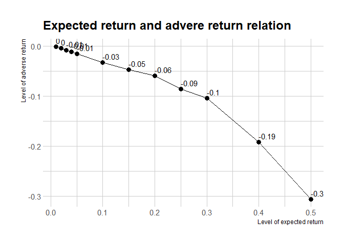

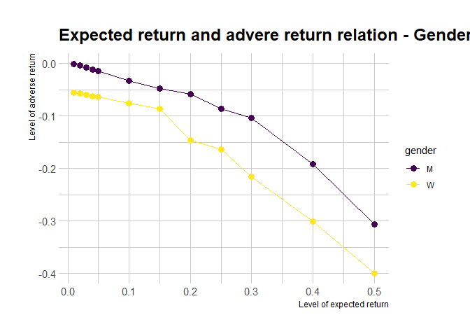

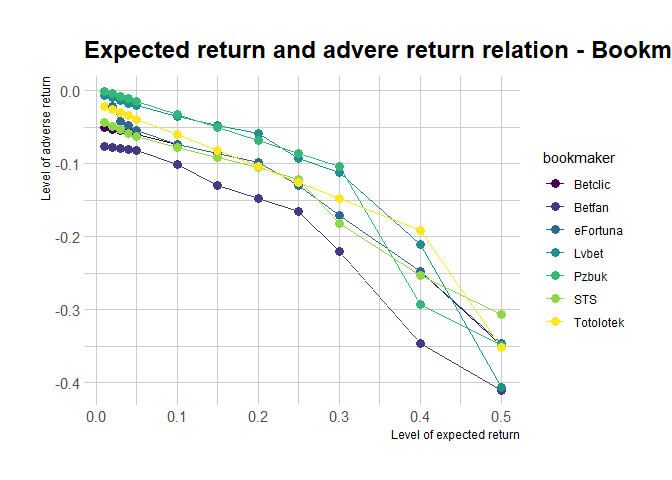

**Disclaimer**

*Please note, that online betting is a gambling entertainment vehicle, and that it carries with it a certain degree of financial risk. Players should be aware of this risk, and govern themselves accordingly.*